# MSDS 430 Module 5 Python Assignment

**In this assignment you will read through the notebook and complete the exercises. Once you are satisfied with the results, submit your notebook and html file to Canvas. Your files should include all output, i.e. run each cell and save your file before submitting.**

### Research project problem statement: There are world happiness surveys conducted every year for many countries around the world. Happiness is measured on such subjective topics as social support, freedom, generosity, corruption, government trust, positive and negative affects.  
This study will look at the happiness measures over multiple years to determine which of the measures are related to the overall happiness of a country. And we will look at population of a country to see if this has any relationship to the happiness measures. Are larger countries based on population happier than smaller countries?  
### Objectives for cleaning and prepping the data: - Read the happiness data and population data into dataframes. - Use the methods `info, head, tail, shape` to inspect the data in the dataframes - Use the method `describe` to obtain some statistics for the numerical data - Create boxplots to check for outliers - Drop null values, drop/select columns, select rows, and rename column names - Use the method `value_counts` to obtain counts of unique rows in a dataframe - Create sub-dataframes by selecting subset of rows and columns - Convert dataframes from wide to long formats - Merge the happiness and population dataframes

### References:

**[World Happiness Report Apendices and Data](https://worldhappiness.report/ed/2022/#appendices-and-data)**

How the indices are calculated for each country: **[World Happiness Report FAQ](https://worldhappiness.report/faq/)**

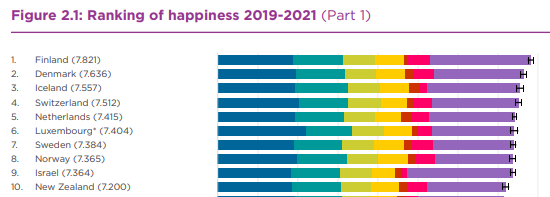

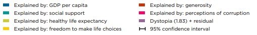

## Part I - Happiness measures

*Below is an example of a table created using HTML. This table explains what each of the happiness variables represents. Check out the code in this Markdown cell to see how to create the table. This format is perfect for a data dictionary which you will be doing in your EDA 2 homework.*

| Measure Name | Description | Source |
| --- | --- | --- |
| GDP per capita | Log of purchasing power parity adjusted to constant 2017 international dollars | World Bank |
| Healthy life expectancy | Life expectancy from birth | World Health Organization |
| Social Support | Subjective response to 'if you were in trouble, do you have relatives or friends to count on...' | Gallup World Poll |
| Freedom | Subjective response to 'Are you satisfied or dissatisfied with your freedom to choose what to do with your life' | Gallop World Poll |
| Generosity | Subjective response to Donating money to charity as relates to GDP per capita | Gallop World Poll |
| Perception of corruption | Subjective response about corruption as it relates to government and to businesses | Gallop World Poll |
| Positive affect | Subjective response to previous day experience of laughter, enjoyment or learn/do something interesting yesterday. | Gallop World Poll |
| Negative affect | Subjective response to previous day experience of worry, sadness, anger. | Gallop World Poll |
| Life ladder | Subjective rating of current life based on the mental image of a ladder with 10 being the highest and 0 for the low | Gallop World Poll |

**Reminder: In all of the problems you will see #TODO statements added as comments on the code cell provided. You will want to be sure to complete each of these as indicated to avoid losing points.**

```python
# Set up notebook to display multiple outputs in one cell
from IPython.core.interactiveshell import InteractiveShell
InteractiveShell.ast_node_interactivity = "all"

import pandas as pd
import numpy as np

# needed for M6
import seaborn as sns
import matplotlib.pyplot as plt

%matplotlib inline
```

### .info() provides a lot of information about a dataframe

- Display the column names, their data types, as well as the non-null value count for each column.
- Also indicate the row index range in `RangeIndex`.
- From the row index range, we know the total number of rows the dataframe contains and the number of null values in each column of the dataframe.

```python
# read in happiness scores
df = pd.read_excel(r'world_happiness_scores.xlsx')
df.info()
```

```
<class 'pandas.core.frame.DataFrame'>
RangeIndex: 2089 entries, 0 to 2088
Data columns (total 12 columns):
 #   Column                             Non-Null Count  Dtype
---  ------                             --------------  -----
 0   Country name                       2089 non-null   object
 1   year                               2089 non-null   int64
 2   Life Ladder                        2089 non-null   float64
 3   Log GDP per capita                 2062 non-null   float64
 4   Social support                     2076 non-null   float64
 5   Healthy life expectancy at birth   2031 non-null   float64
 6   Freedom to make life choices       2057 non-null   float64
 7   Generosity                         2009 non-null   float64
 8   Perceptions of corruption          1976 non-null   float64
 9   Positive affect                    2065 non-null   float64
 10  Negative affect                    2073 non-null   float64
 11  Confidence in national government  1873 non-null   float64
dtypes: float64(10), int64(1), object(1)
memory usage: 196.0+ KB
```

### Additional info on data

- Use the DataFrame `head()` and `tail()` methods to become familiar with the data values. For example, the higher the values of **Social Support**, the **better** for the country, while the higher the value of **Perceptions of corruption** the **worse** the condition.

```python
df.head()
df.tail()
```

|  | Country name | year | Life Ladder | Log GDP per capita | Social support | Healthy life expectancy at birth | Freedom to make life choices | Generosity | Perceptions of corruption | Positive affect | Negative affect | Confidence in national government |
| --- | --- | --- | --- | --- | --- | --- | --- | --- | --- | --- | --- | --- |
| 0 | Afghanistan | 2008 | 3.723590 | 7.302574 | 0.450662 | 50.500000 | 0.718114 | 0.173169 | 0.881686 | 0.414297 | 0.258195 | 0.612072 |
| 1 | Afghanistan | 2009 | 4.401778 | 7.472446 | 0.552308 | 50.799999 | 0.678896 | 0.195469 | 0.850035 | 0.481421 | 0.237092 | 0.611545 |
| 2 | Afghanistan | 2010 | 4.758381 | 7.579183 | 0.539075 | 51.099998 | 0.600127 | 0.125859 | 0.706766 | 0.516907 | 0.275324 | 0.299357 |
| 3 | Afghanistan | 2011 | 3.831719 | 7.552006 | 0.521104 | 51.400002 | 0.495901 | 0.167723 | 0.731109 | 0.479835 | 0.267175 | 0.307386 |
| 4 | Afghanistan | 2012 | 3.782938 | 7.637953 | 0.520637 | 51.700001 | 0.530935 | 0.241247 | 0.775620 | 0.613513 | 0.267919 | 0.435440 |

|  | Country name | year | Life Ladder | Log GDP per capita | Social support | Healthy life expectancy at birth | Freedom to make life choices | Generosity | Perceptions of corruption | Positive affect | Negative affect | Confidence in national government |
| --- | --- | --- | --- | --- | --- | --- | --- | --- | --- | --- | --- | --- |
| 2084 | Zimbabwe | 2017 | 3.638300 | 8.241609 | 0.754147 | 52.150002 | 0.752826 | -0.113937 | 0.751208 | 0.733641 | 0.224051 | 0.682647 |
| 2085 | Zimbabwe | 2018 | 3.616480 | 8.274620 | 0.775388 | 52.625000 | 0.762675 | -0.084747 | 0.844209 | 0.657524 | 0.211726 | 0.550508 |
| 2086 | Zimbabwe | 2019 | 2.693523 | 8.196998 | 0.759162 | 53.099998 | 0.631908 | -0.081540 | 0.830652 | 0.658434 | 0.235354 | 0.456455 |
| 2087 | Zimbabwe | 2020 | 3.159802 | 8.117733 | 0.717243 | 53.575001 | 0.643303 | -0.029376 | 0.788523 | 0.660658 | 0.345736 | 0.577302 |
| 2088 | Zimbabwe | 2021 | 3.154578 | 8.153248 | 0.685151 | 54.049999 | 0.667636 | -0.109439 | 0.756945 | 0.609917 | 0.241682 | 0.665703 |

### Descriptive statistics

`describe()` shows each numerical column along with the count, mean and standard deviation for each.

```python
# look at the statitics of each numerical variable
df.describe()
```

|  | year | Life Ladder | Log GDP per capita | Social support | Healthy life expectancy at birth | Freedom to make life choices | Generosity | Perceptions of corruption | Positive affect | Negative affect | Confidence in national government |
| --- | --- | --- | --- | --- | --- | --- | --- | --- | --- | --- | --- |
| count | 2089.000000 | 2089.000000 | 2062.000000 | 2076.000000 | 2031.000000 | 2057.000000 | 2009.000000 | 1976.000000 | 2065.000000 | 2073.000000 | 1873.000000 |
| mean | 2013.727621 | 5.473747 | 9.378408 | 0.811542 | 63.180326 | 0.745462 | 0.000102 | 0.746474 | 0.651421 | 0.270544 | 0.483914 |
| std | 4.455614 | 1.115567 | 1.143520 | 0.118935 | 6.948546 | 0.140751 | 0.161082 | 0.186136 | 0.105954 | 0.085849 | 0.191515 |
| min | 2005.000000 | 2.178809 | 5.526723 | 0.290184 | 6.720000 | 0.257534 | -0.335739 | 0.035198 | 0.178886 | 0.082737 | 0.068769 |
| 25% | 2010.000000 | 4.651972 | 8.473547 | 0.747664 | 58.965000 | 0.651689 | -0.113172 | 0.689840 | 0.570057 | 0.207652 | 0.334808 |
| 50% | 2014.000000 | 5.405246 | 9.463269 | 0.834770 | 64.980003 | 0.767357 | -0.023366 | 0.801339 | 0.662837 | 0.260328 | 0.467046 |
| 75% | 2017.000000 | 6.294282 | 10.347656 | 0.904682 | 68.362499 | 0.857677 | 0.090584 | 0.870789 | 0.737176 | 0.321706 | 0.616302 |
| max | 2021.000000 | 8.018934 | 11.665803 | 0.987343 | 74.349998 | 0.985178 | 0.706377 | 0.983276 | 0.883586 | 0.704590 | 0.993604 |

### Renaming column names

- We can use the `rename()` method to rename one or more of a dataframe's columns
- Create a dictionary with old and new column names represented as `key` and `value` pairs:  
  `{'old column name 1':'new column name 1', 'old column name 2':'new column name 2',...}`.
- Assign this dictionary to the `columns` parameter of the `rename()` method
- Note that you must use the *exact* names for the columns you renaming which includes spaces, casing and any symbols

```python
# create useable column names
df = df.rename(columns = {'Country name':'Country',
                          'year':'Year'})
df.info()
```

```
<class 'pandas.core.frame.DataFrame'>
RangeIndex: 2089 entries, 0 to 2088
Data columns (total 12 columns):
 #   Column                             Non-Null Count  Dtype
---  ------                             --------------  -----
 0   Country                            2089 non-null   object
 1   Year                               2089 non-null   int64
 2   Life Ladder                        2089 non-null   float64
 3   Log GDP per capita                 2062 non-null   float64
 4   Social support                     2076 non-null   float64
 5   Healthy life expectancy at birth   2031 non-null   float64
 6   Freedom to make life choices       2057 non-null   float64
 7   Generosity                         2009 non-null   float64
 8   Perceptions of corruption          1976 non-null   float64
 9   Positive affect                    2065 non-null   float64
 10  Negative affect                    2073 non-null   float64
 11  Confidence in national government  1873 non-null   float64
dtypes: float64(10), int64(1), object(1)
memory usage: 196.0+ KB
```

**Problem 1 (2 pts.)**: Rename the columns as described below and do an info statement after to show the changes: - Log GDP per capita becomes: Log GDP - Healthy life expectancy at birth becomes: Life Expectancy - Freedom to make life choices becomes: Choice Freedom - Perceptions of corruption becomes: Corruption - Confidence in national government becomes: Government confidence

```python
#TODO: Rename columns as indicated in the instructions
df = df.rename(columns = {'Log GDP per capita':'Log GDP',
                          'Healthy life expectancy at birth':'Life Expectancy',
                          'Freedom to make life choices':'Choice Freedom',
                          'Perceptions of corruption':'Corruption',
                          'Confidence in national government':'Government Confidence'})

#TODO: Display the dataframe info
df.info()
```

```
<class 'pandas.core.frame.DataFrame'>
RangeIndex: 2089 entries, 0 to 2088
Data columns (total 12 columns):
 #   Column                 Non-Null Count  Dtype
---  ------                 --------------  -----
 0   Country                2089 non-null   object
 1   Year                   2089 non-null   int64
 2   Life Ladder            2089 non-null   float64
 3   Log GDP                2062 non-null   float64
 4   Social support         2076 non-null   float64
 5   Life Expectancy        2031 non-null   float64
 6   Choice Freedom         2057 non-null   float64
 7   Generosity             2009 non-null   float64
 8   Corruption             1976 non-null   float64
 9   Positive affect        2065 non-null   float64
 10  Negative affect        2073 non-null   float64
 11  Government Confidence  1873 non-null   float64
dtypes: float64(10), int64(1), object(1)
memory usage: 196.0+ KB
```

### Evaluating field types

Take a look at each column type to determine if the type should stay as is or be changed. `Year` is an int64 and `ints` and `floats` are normally used for mathematical calculations. Since we only need to use Year as a label, let's change it to a string object.

Pandas function `astype()` will change a pandas column data type. For for info see: **[Pandas astype](https://pandas.pydata.org/pandas-docs/stable/reference/api/pandas.DataFrame.astype.html)**

```python
df['Year'] = df['Year'].astype('str')
df.info()
```

```
<class 'pandas.core.frame.DataFrame'>
RangeIndex: 2089 entries, 0 to 2088
Data columns (total 12 columns):
 #   Column                 Non-Null Count  Dtype
---  ------                 --------------  -----
 0   Country                2089 non-null   object
 1   Year                   2089 non-null   object
 2   Life Ladder            2089 non-null   float64
 3   Log GDP                2062 non-null   float64
 4   Social support         2076 non-null   float64
 5   Life Expectancy        2031 non-null   float64
 6   Choice Freedom         2057 non-null   float64
 7   Generosity             2009 non-null   float64
 8   Corruption             1976 non-null   float64
 9   Positive affect        2065 non-null   float64
 10  Negative affect        2073 non-null   float64
 11  Government Confidence  1873 non-null   float64
dtypes: float64(10), object(2)
memory usage: 196.0+ KB
```

### Looking for outliers by using a boxplot

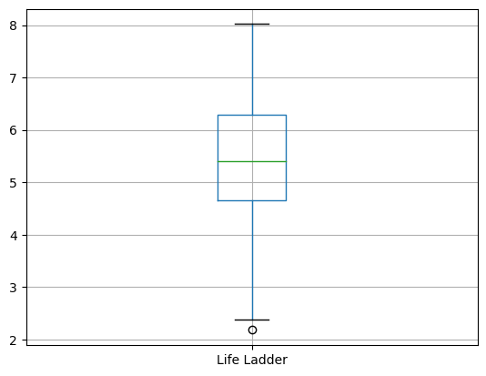

```python
df.boxplot(column = 'Life Ladder')
# will rotate x axis label
#df.boxplot(column = 'Life Ladder', rot = 55)
```

### Side by side boxplots

Often it is good to do side by side boxplots of the columns so you can see how columns are similar or different.

Scroll back up to the cell where `.describe()` was run to look at the spread of the values of the numeric columns. Look at how some of the variables, like `Life Expectancy`, is so much larger than the other variables. Putting such disimilar data side by side will make one of the boxplots too small and too hard to read.

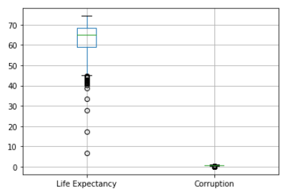

**Problem 2 (4 pts.)**: You need to inspect each numeric field for outliers. Run a set of boxplots for: - Side by side boxplots for all seven happiness measures that have a max under 1. - Individual boxplots for Life Expectancy and Log GDP

[output not shown]

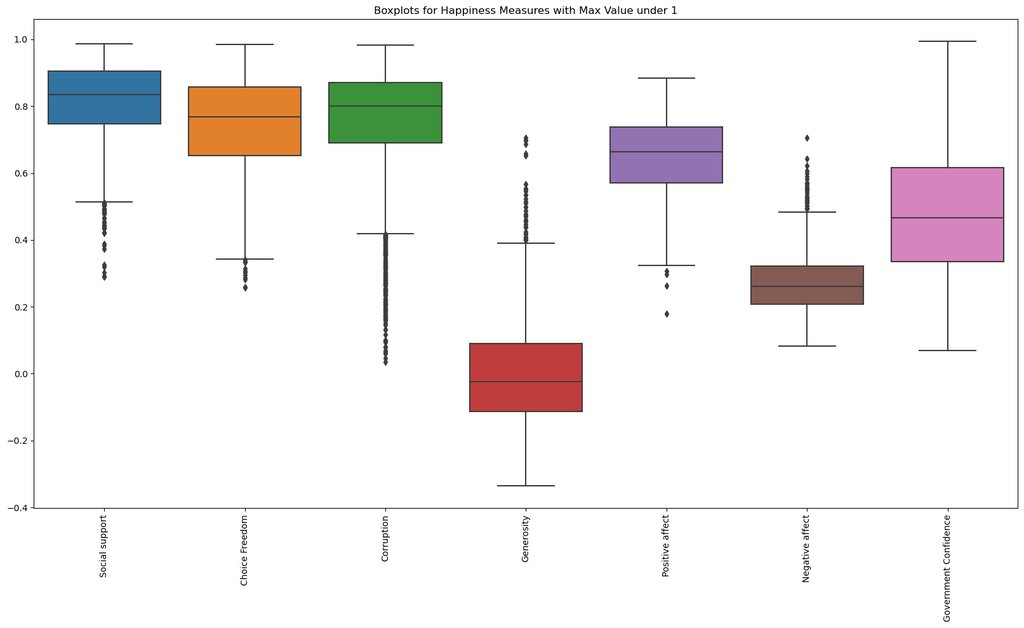

```python
# Make a list of happiness measures
happiness_measures = ['Life Ladder', 'Social support', 'Choice Freedom', 'Corruption' ,
                      'Generosity', 'Positive affect', 'Negative affect', 'Government Confidence']
# Filter columns with max value under 1
cols_max_under_1 = [col for col in happiness_measures if df[col].max() < 1]
# TO DO show side by side boxplots of seven measures
plt.figure(figsize=(20,10))
sns.boxplot(data=df[cols_max_under_1])
plt.title('Boxplots for Happiness Measures with Max Value under 1')
plt.xticks(rotation=90)
plt.show()
```

**Problem 2 continued:** Create a boxplot for *Life Expectancy*.

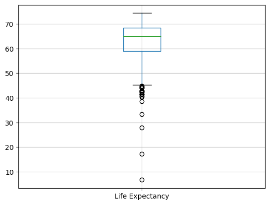

```python
#TODO: Create a boxplot for Life Expectancy
df.boxplot(column = 'Life Expectancy')
```

**Problem 2 continued:** Create a boxplot for *Log GDP*.

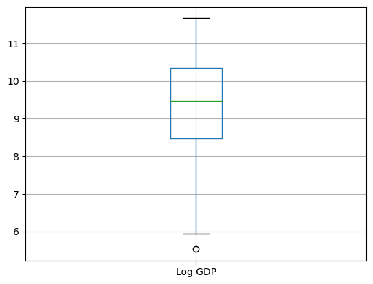

```python
#TODO: Create a boxplot for Log GDP
df.boxplot(column = 'Log GDP')
```

**Problem 3 (2 pts.)**: Use a markdown cell to explain what each of the boxplots in Problem 2 shows.

The significant number of outliers in the Life-Expectancy dataset suggests a wide variation in global life expectancy, potentially driven by diverse factors. Investigating these outliers could yield valuable insights.

In contrast, the Log GDP dataset, with only one outlier, suggests a more consistent global economic output on a logarithmic scale.

Both datasets' left-skewness implies that most nations have higher life expectancies and GDPs. The higher skewness in Life-Expectancy indicates that its influencing factors may be more varied than those for Log GDP, suggesting life expectancy is influenced by more than just economic performance. A detailed analysis can offer a more holistic view of global well-being factors.

### Inspection of the `Year` field

We can see below that the earlier years along with 2020 and 2021 have fewer countries represented. It looks like 2011 through 2019 have a fairly consistent number of countries, but before we decide which years to use, we will investigate the `Year` column.

```python
# using sort_index puts the order focus on the field and not the count
df['Year'].value_counts().sort_index()
```

```
2005     27
2006     89
2007    102
2008    110
2009    114
2010    124
2011    146
2012    142
2013    137
2014    145
2015    143
2016    142
2017    147
2018    142
2019    144
2020    116
2021    119
Name: Year, dtype: int64
```

### Investigate one year of data

Below we are creating a new dataframe object with only 2011 data.

```python
yr2011 = df[df['Year'] == '2011']
yr2011.info()
yr2011.head()
```

```
<class 'pandas.core.frame.DataFrame'>
Int64Index: 146 entries, 3 to 2078
Data columns (total 12 columns):
 #   Column                 Non-Null Count  Dtype
---  ------                 --------------  -----
 0   Country                146 non-null    object
 1   Year                   146 non-null    object
 2   Life Ladder            146 non-null    float64
 3   Log GDP                145 non-null    float64
 4   Social support         145 non-null    float64
 5   Life Expectancy        141 non-null    float64
 6   Choice Freedom         145 non-null    float64
 7   Generosity             144 non-null    float64
 8   Corruption             138 non-null    float64
 9   Positive affect        145 non-null    float64
 10  Negative affect        146 non-null    float64
 11  Government Confidence  122 non-null    float64
dtypes: float64(10), object(2)
memory usage: 14.8+ KB
```

|  | Country | Year | Life Ladder | Log GDP | Social support | Life Expectancy | Choice Freedom | Generosity | Corruption | Positive affect | Negative affect | Government Confidence |
| --- | --- | --- | --- | --- | --- | --- | --- | --- | --- | --- | --- | --- |
| 3 | Afghanistan | 2011 | 3.831719 | 7.552006 | 0.521104 | 51.400002 | 0.495901 | 0.167723 | 0.731109 | 0.479835 | 0.267175 | 0.307386 |
| 16 | Albania | 2011 | 5.867422 | 9.310439 | 0.759434 | 67.879997 | 0.487496 | -0.204296 | 0.877003 | 0.565759 | 0.256577 | NaN |
| 28 | Algeria | 2011 | 5.317194 | 9.312737 | 0.810234 | 65.599998 | 0.529561 | -0.182975 | 0.637982 | 0.502736 | 0.254897 | NaN |
| 37 | Angola | 2011 | 5.589001 | 8.945782 | 0.723094 | 51.220001 | 0.583702 | 0.054426 | 0.911320 | 0.666833 | 0.361063 | 0.232387 |
| 46 | Argentina | 2011 | 6.775805 | 10.112436 | 0.889073 | 66.419998 | 0.815802 | -0.175919 | 0.754646 | 0.768943 | 0.231855 | 0.607538 |

### View the country names for the year 2011

- Think of which names may need correcting - like Hong Kong and Taiwan. Country names will be used later to connect with population data and the country names in both data frames will need to match.
- Inspect to see if there are more than country info included.
- Note the `pd.options` line which allows you to see all the rows of country names. Once you run this code for a notebook, it is set as long as the notebook is active.

```python
#https://pandas.pydata.org/pandas-docs/stable/user_guide/options.html
#pd.options.display.max_rows = 999

# can only see some of the rows
print(yr2011['Country'])
```

```
3       Afghanistan
16          Albania
28          Algeria
37           Angola
46        Argentina
           ...
2019      Venezuela
2035        Vietnam
2049          Yemen
2062         Zambia
2078       Zimbabwe
Name: Country, Length: 146, dtype: object
```

### pd.options.display - note the output now

When you look at the output in the previous cell, the first five countries are shown and the last five countries are shown; the countries in between are not visible. You can set the number of maximum rows to show with the `pd.options.display` command. In the cell below, the `max_rows` is set to 999 and all countries are displayed. The setting is now in place for the remaining use of the notebook.

```python
#https://pandas.pydata.org/pandas-docs/stable/user_guide/options.html

# can now see all of the rows
pd.options.display.max_rows = 999
print(yr2011['Country'])
```

```
3                     Afghanistan
16                        Albania
28                        Algeria
37                         Angola
46                      Argentina
62                        Armenia
76                      Australia
90                        Austria
106                    Azerbaijan
117                       Bahrain
131                    Bangladesh
146                       Belarus
159                       Belgium
173                         Benin
192                       Bolivia
```

[output cut: 132 more lines]

### Investigate the years to determine which should be included in the analysis

```python
years = ['2015', '2016', '2017', '2018', '2019', '2020', '2021']

many_years = df[df['Year'].isin(years)]
many_years.info()
```

```
<class 'pandas.core.frame.DataFrame'>
Int64Index: 953 entries, 7 to 2088
Data columns (total 12 columns):
 #   Column                 Non-Null Count  Dtype
---  ------                 --------------  -----
 0   Country                953 non-null    object
 1   Year                   953 non-null    object
 2   Life Ladder            953 non-null    float64
 3   Log GDP                936 non-null    float64
 4   Social support         951 non-null    float64
 5   Life Expectancy        925 non-null    float64
 6   Choice Freedom         943 non-null    float64
 7   Generosity             932 non-null    float64
 8   Corruption             897 non-null    float64
 9   Positive affect        947 non-null    float64
 10  Negative affect        947 non-null    float64
 11  Government Confidence  861 non-null    float64
dtypes: float64(10), object(2)
memory usage: 96.8+ KB
```

### Missing values

- Any row in the dataframe that does not have 953 non-null rows of data has missing data.
- It is important to consider how a row of data can be recovered if at all possible.
- In some data, there may be columns that can help populate other columns.
  - For example, a missing `Age` value can be calculated from a `Birth_date` column.
- It turns out with the data we are using, there is no way to fill in the gaps from other columns.
- The option for this data is to drop all of the null rows.

```python
many_years = many_years.dropna(inplace = False)
many_years.info()
```

```
<class 'pandas.core.frame.DataFrame'>
Int64Index: 820 entries, 7 to 2088
Data columns (total 12 columns):
 #   Column                 Non-Null Count  Dtype
---  ------                 --------------  -----
 0   Country                820 non-null    object
 1   Year                   820 non-null    object
 2   Life Ladder            820 non-null    float64
 3   Log GDP                820 non-null    float64
 4   Social support         820 non-null    float64
 5   Life Expectancy        820 non-null    float64
 6   Choice Freedom         820 non-null    float64
 7   Generosity             820 non-null    float64
 8   Corruption             820 non-null    float64
 9   Positive affect        820 non-null    float64
 10  Negative affect        820 non-null    float64
 11  Government Confidence  820 non-null    float64
dtypes: float64(10), object(2)
memory usage: 83.3+ KB
```

### Happiness data by years

From the `value_counts` counts in the cell below, there are between 122 and 128 countries with data for the years of 2015-2019. But the number of countries drop in 2020 to 99 and in 2021 to 100.

```python
# look at counts per year without nulls
many_years['Year'].value_counts().sort_index()
```

```
2015    125
2016    123
2017    128
2018    123
2019    122
2020     99
2021    100
Name: Year, dtype: int64
```

### Pandas Crosstab

**[Pandas Crosstab](https://pandas.pydata.org/docs/reference/api/pandas.crosstab.html)**

```python
# look at Country and year to see what is missing
# margins = True gives a row and column total
cross = pd.crosstab(many_years['Country'],many_years['Year'], margins = True)
cross
```

| Year Country | 2015 | 2016 | 2017 | 2018 | 2019 | 2020 | 2021 | All |
| --- | --- | --- | --- | --- | --- | --- | --- | --- |
| Afghanistan | 1 | 1 | 1 | 1 | 1 | 0 | 0 | 5 |
| Albania | 1 | 1 | 1 | 1 | 1 | 1 | 1 | 7 |
| Argentina | 1 | 1 | 1 | 1 | 1 | 1 | 1 | 7 |
| Armenia | 1 | 1 | 1 | 1 | 1 | 0 | 1 | 6 |
| Australia | 1 | 1 | 1 | 1 | 1 | 1 | 1 | 7 |
| Austria | 1 | 1 | 1 | 1 | 1 | 1 | 1 | 7 |
| Azerbaijan | 1 | 1 | 1 | 1 | 1 | 0 | 0 | 5 |
| Bangladesh | 1 | 1 | 1 | 1 | 1 | 1 | 0 | 6 |
| Belarus | 1 | 1 | 1 | 1 | 1 | 0 | 0 | 5 |
| Belgium | 1 | 1 | 1 | 1 | 1 | 1 | 0 | 6 |
| Benin | 1 | 1 | 1 | 1 | 1 | 1 | 1 | 7 |
| Bhutan | 1 | 0 | 0 | 0 | 0 | 0 | 0 | 1 |
| Bolivia | 1 | 1 | 1 | 1 | 1 | 1 | 1 | 7 |
| Bosnia and Herzegovina | 1 | 1 | 1 | 1 | 1 | 1 | 1 | 7 |
| Botswana | 1 | 1 | 1 | 1 | 1 | 0 | 0 | 5 |
| Brazil | 1 | 1 | 1 | 1 | 1 | 1 | 1 | 7 |
| Bulgaria | 1 | 1 | 1 | 1 | 1 | 1 | 1 | 7 |
| Burkina Faso | 1 | 1 | 1 | 1 | 1 | 1 | 1 | 7 |
| Cambodia | 1 | 1 | 1 | 0 | 0 | 0 | 0 | 3 |
| Cameroon | 1 | 1 | 1 | 1 | 1 | 1 | 1 | 7 |
| Canada | 1 | 1 | 1 | 1 | 1 | 1 | 1 | 7 |
| Central African Republic | 0 | 1 | 1 | 0 | 0 | 0 | 0 | 2 |
| Chad | 1 | 1 | 1 | 1 | 1 | 0 | 0 | 5 |
| Chile | 1 | 1 | 1 | 1 | 1 | 1 | 1 | 7 |
| Colombia | 1 | 1 | 1 | 1 | 1 | 1 | 1 | 7 |
| Comoros | 0 | 0 | 0 | 1 | 1 | 0 | 0 | 2 |
| Congo (Brazzaville) | 1 | 1 | 1 | 1 | 1 | 1 | 1 | 7 |
| Congo (Kinshasa) | 1 | 1 | 1 | 0 | 0 | 0 | 0 | 3 |
| Costa Rica | 1 | 1 | 1 | 1 | 1 | 1 | 1 | 7 |
| Croatia | 1 | 1 | 1 | 1 | 1 | 1 | 1 | 7 |

[output cut: 108 more lines]

### Results of crosstab

A visual inspection of the crosstab does reveal the countries with no data for 2020 and 2021. There are enough major countries with missing data that it will be better off for our study to omit 2020 and 2021. The cell below shows the isolation of countries with five or less years of data.

### Best practice on dataframe names

- As you progress in the EDA process, there will end up being many dataframes created. A naming convention is a good plan to put into place. Your naming convention should be one that makes sense to you and to anyone that you will share your code with.
- A common mistake made is to use nonmeaningful names like df1, df2, df3, etc. The weakness with this plan is that it is difficult to easily know which is the most current dataframe.
- A possible convention is to use `df` following by a suffix which denotes where you are in the EDA process.
  - df_raw or dfRaw could be used when you first read in the raw data.
  - df_clean or dfClean could be used after cleaning the data
  - df_final or dfFinal could be used after creating new variables and you are ready to write out your file.
  - There can be a number of additional suffixes that you may end up using.
- Another convention is to use dataframe names that relate to your topic; this is especially useful if you have a number of files.
  - Example: nfl2019, nfl2020, nfl2021 would be good names if you have three years of data that you will later combine.
  - You can use this example and combine it with the suffix idea: nfl2019Raw, nfl2019Clean, nfl2019Final.

**Problem 4 (4 pts.)**: Create a new dataframe called `happy_final` to include 2015, 2016, 2017, 2018 and 2019 data. - Show the shape of your new dataframe. - Drop all nulls from happy_final. - Show the shape of the dataframe after the drop. Make sure the number of records have decreased.

```python
#TODO: Create dataframe called 'happy_final'
years = ['2015', '2016', '2017', '2018', '2019']
happy_final = df[df['Year'].isin(years)]
```

```python
#TODO: Show the shape of happy_final dataframe
happy_final.shape
#TODO: drop the nulls from happy_final
happy_final = happy_final.dropna(inplace = False)
#TODO: Show the shape of happy_final dataframe
happy_final.shape
```

```
(718, 12)
```

```
(621, 12)
```

### Dataframe names continued

In the cell below there are two new dataframes created, `cross` and `subset`. These names were chosen in such a way that they can be used again and again without the worry that they will interfere with or be overwritten by a dataframe that might be needed later.

```python
#  what is missing per country
cross = pd.crosstab(happy_final['Country'],happy_final['Year'], margins = True)
type(cross)
subset = cross[cross['All'] < 5]
type(subset)
subset.sort_values(by = 'All')
```

```
pandas.core.frame.DataFrame
```

```
pandas.core.frame.DataFrame
```

| Year Country | 2015 | 2016 | 2017 | 2018 | 2019 | All |
| --- | --- | --- | --- | --- | --- | --- |
| Bhutan | 1 | 0 | 0 | 0 | 0 | 1 |
| Trinidad and Tobago | 0 | 0 | 1 | 0 | 0 | 1 |
| Laos | 0 | 0 | 1 | 0 | 0 | 1 |
| Somalia | 1 | 1 | 0 | 0 | 0 | 2 |
| Eswatini | 0 | 0 | 0 | 1 | 1 | 2 |
| Egypt | 1 | 1 | 0 | 0 | 0 | 2 |
| Jamaica | 0 | 0 | 1 | 0 | 1 | 2 |
| Yemen | 1 | 0 | 0 | 1 | 0 | 2 |
| Central African Republic | 0 | 1 | 1 | 0 | 0 | 2 |
| Comoros | 0 | 0 | 0 | 1 | 1 | 2 |
| Cambodia | 1 | 1 | 1 | 0 | 0 | 3 |
| Tajikistan | 1 | 1 | 1 | 0 | 0 | 3 |
| Namibia | 0 | 0 | 1 | 1 | 1 | 3 |
| Malaysia | 1 | 0 | 0 | 1 | 1 | 3 |
| Lesotho | 0 | 1 | 1 | 0 | 1 | 3 |
| Congo (Kinshasa) | 1 | 1 | 1 | 0 | 0 | 3 |
| Iceland | 1 | 1 | 1 | 0 | 0 | 3 |
| Gambia | 0 | 0 | 1 | 1 | 1 | 3 |
| Iraq | 1 | 1 | 1 | 1 | 0 | 4 |
| Czechia | 1 | 1 | 1 | 1 | 0 | 4 |
| Mozambique | 1 | 0 | 1 | 1 | 1 | 4 |
| Iran | 1 | 1 | 0 | 1 | 1 | 4 |
| Paraguay | 1 | 1 | 1 | 0 | 1 | 4 |
| Rwanda | 0 | 1 | 1 | 1 | 1 | 4 |
| Sri Lanka | 1 | 0 | 1 | 1 | 1 | 4 |
| Haiti | 1 | 1 | 1 | 1 | 0 | 4 |
| Uzbekistan | 1 | 0 | 1 | 1 | 1 | 4 |
| Mauritius | 0 | 1 | 1 | 1 | 1 | 4 |

### Happiness data wrap up

At this point the happiness data is ready to be merged with the population data. Even though there are some years missing from some of the countries, the merge process will only select those countries and years with both happiness data and population data.

## Part II - Population data

**[Worldbank Data](https://data.worldbank.org/indicator/SP.POP.TOTL)**

When you look at the data in the popuation file, you can see that the first row is not the header.

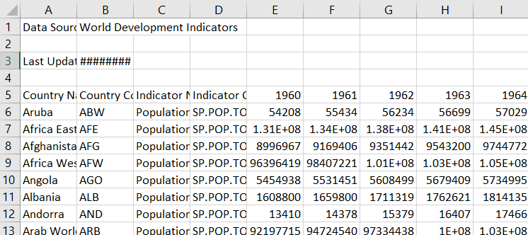

### Big picture plan of merging two dataframes

Our goal is to create one final dataframe that contains data for the happiness measures and population data. Here are some important details to know about merging dataframes.

- You will need common fields in each dataframe to merge on and in our case it is two columns - `Country and Year`.
- For every `Country+Year` combination, we will have one row of data.
- The merge of data will be an inner join between the two tables so that we end up with both happiness and population data. If one dataframe has data for the `Country+Year` combination of a row but not the other file, then that data is dropped.
- For example, if there is Population data for Egypt for 2019, but no happiness data, then the Egypt+2019 row of data is dropped completely from our final clean dataframe.

**Problem 5 (3 pts.)**: Read in csv file that contains the population data. - The file name is API_SP.POP.TOTL_DS2_en_csv_v2_4683828.csv. This is the actual name downloaded from the site. - Call your new dataframe `pop_raw`. - Make sure you have a proper header. - Display the first ten records and the info about the file.

```python
# TODO: Read in the file
pop_raw = pd.read_csv('API_SP.POP.TOTL_DS2_en_csv_v2_4683828.csv')
# Shows the fist 5 rows
pop_raw.head()
# Drops the first three rows, because these rows contain the metadata
pop_raw = pop_raw.iloc[3:].reset_index(drop=True)
# Cleans the header row - removes .0 from years and converts the header-row to str
pop_raw.iloc[0] = pop_raw.iloc[0].apply(lambda x: str(int(x)) if str(x).endswith('.0') else str(x))
# Makes the first row the file, the header
pop_raw.columns = pop_raw.iloc[0]
# Resets the index of the file
pop_raw = pop_raw.iloc[1:].reset_index(drop=True)
# Shows the first 5 rows, with the corrected header
pop_raw.head()
#TODO: Display the dataframe info the info about the file
pop_raw.info()
```

|  | Data Source | World Development Indicators | Unnamed: 2 | Unnamed: 3 | Unnamed: 4 | Unnamed: 5 | Unnamed: 6 | Unnamed: 7 | Unnamed: 8 | Unnamed: 9 | ... | Unnamed: 56 | Unnamed: 57 | Unnamed: 58 | Unnamed: 59 | Unnamed: 60 | Unnamed: 61 | Unnamed: 62 | Unnamed: 63 | Unnamed: 64 | Unnamed: 65 |
| --- | --- | --- | --- | --- | --- | --- | --- | --- | --- | --- | --- | --- | --- | --- | --- | --- | --- | --- | --- | --- | --- |
| 0 | NaN | NaN | NaN | NaN | NaN | NaN | NaN | NaN | NaN | NaN | ... | NaN | NaN | NaN | NaN | NaN | NaN | NaN | NaN | NaN | NaN |
| 1 | Last Updated Date | 16-09-2022 | NaN | NaN | NaN | NaN | NaN | NaN | NaN | NaN | ... | NaN | NaN | NaN | NaN | NaN | NaN | NaN | NaN | NaN | NaN |
| 2 | NaN | NaN | NaN | NaN | NaN | NaN | NaN | NaN | NaN | NaN | ... | NaN | NaN | NaN | NaN | NaN | NaN | NaN | NaN | NaN | NaN |
| 3 | Country Name | Country Code | Indicator Name | Indicator Code | 1960.0 | 1961.0 | 1962.0 | 1963.0 | 1964.0 | 1965.0 | ... | 2012.0 | 2013.0 | 2014.0 | 2015.0 | 2016.0 | 2017.0 | 2018.0 | 2019.0 | 2020.0 | 2021.0 |
| 4 | Aruba | ABW | Population, total | SP.POP.TOTL | 54208.0 | 55434.0 | 56234.0 | 56699.0 | 57029.0 | 57357.0 | ... | 102565.0 | 103165.0 | 103776.0 | 104339.0 | 104865.0 | 105361.0 | 105846.0 | 106310.0 | 106766.0 | 107195.0 |

5 rows × 66 columns

|  | Country Name | Country Code | Indicator Name | Indicator Code | 1960 | 1961 | 1962 | 1963 | 1964 | 1965 | ... | 2012 | 2013 | 2014 | 2015 | 2016 | 2017 | 2018 | 2019 | 2020 | 2021 |
| --- | --- | --- | --- | --- | --- | --- | --- | --- | --- | --- | --- | --- | --- | --- | --- | --- | --- | --- | --- | --- | --- |
| 0 | Aruba | ABW | Population, total | SP.POP.TOTL | 54208.0 | 55434.0 | 56234.0 | 56699.0 | 57029.0 | 57357.0 | ... | 102565.0 | 103165.0 | 103776.0 | 104339.0 | 104865.0 | 105361.0 | 105846.0 | 106310.0 | 106766.0 | 107195.0 |
| 1 | Africa Eastern and Southern | AFE | Population, total | SP.POP.TOTL | 130836765.0 | 134159786.0 | 137614644.0 | 141202036.0 | 144920186.0 | 148769974.0 | ... | 547482863.0 | 562601578.0 | 578075373.0 | 593871847.0 | 609978946.0 | 626392880.0 | 643090131.0 | 660046272.0 | 677243299.0 | 694665117.0 |
| 2 | Afghanistan | AFG | Population, total | SP.POP.TOTL | 8996967.0 | 9169406.0 | 9351442.0 | 9543200.0 | 9744772.0 | 9956318.0 | ... | 31161378.0 | 32269592.0 | 33370804.0 | 34413603.0 | 35383028.0 | 36296111.0 | 37171922.0 | 38041757.0 | 38928341.0 | 39835428.0 |
| 3 | Africa Western and Central | AFW | Population, total | SP.POP.TOTL | 96396419.0 | 98407221.0 | 100506960.0 | 102691339.0 | 104953470.0 | 107289875.0 | ... | 370243017.0 | 380437896.0 | 390882979.0 | 401586651.0 | 412551299.0 | 423769930.0 | 435229381.0 | 446911598.0 | 458803476.0 | 470898870.0 |
| 4 | Angola | AGO | Population, total | SP.POP.TOTL | 5454938.0 | 5531451.0 | 5608499.0 | 5679409.0 | 5734995.0 | 5770573.0 | ... | 25107925.0 | 26015786.0 | 26941773.0 | 27884380.0 | 28842482.0 | 29816769.0 | 30809787.0 | 31825299.0 | 32866268.0 | 33933611.0 |

5 rows × 66 columns

```
<class 'pandas.core.frame.DataFrame'>
RangeIndex: 266 entries, 0 to 265
Data columns (total 66 columns):
 #   Column          Non-Null Count  Dtype
---  ------          --------------  -----
 0   Country Name    266 non-null    object
 1   Country Code    266 non-null    object
 2   Indicator Name  266 non-null    object
 3   Indicator Code  266 non-null    object
 4   1960            264 non-null    object
 5   1961            264 non-null    object
 6   1962            264 non-null    object
 7   1963            264 non-null    object
 8   1964            264 non-null    object
 9   1965            264 non-null    object
```

[output cut: 58 more lines]

**Problem 5 continued:** Display the first ten records.

```python
#TODO: Display the first ten records
pop_raw.head(10)
```

|  | Country Name | Country Code | Indicator Name | Indicator Code | 1960 | 1961 | 1962 | 1963 | 1964 | 1965 | ... | 2012 | 2013 | 2014 | 2015 | 2016 | 2017 | 2018 | 2019 | 2020 | 2021 |
| --- | --- | --- | --- | --- | --- | --- | --- | --- | --- | --- | --- | --- | --- | --- | --- | --- | --- | --- | --- | --- | --- |
| 0 | Aruba | ABW | Population, total | SP.POP.TOTL | 54208.0 | 55434.0 | 56234.0 | 56699.0 | 57029.0 | 57357.0 | ... | 102565.0 | 103165.0 | 103776.0 | 104339.0 | 104865.0 | 105361.0 | 105846.0 | 106310.0 | 106766.0 | 107195.0 |
| 1 | Africa Eastern and Southern | AFE | Population, total | SP.POP.TOTL | 130836765.0 | 134159786.0 | 137614644.0 | 141202036.0 | 144920186.0 | 148769974.0 | ... | 547482863.0 | 562601578.0 | 578075373.0 | 593871847.0 | 609978946.0 | 626392880.0 | 643090131.0 | 660046272.0 | 677243299.0 | 694665117.0 |
| 2 | Afghanistan | AFG | Population, total | SP.POP.TOTL | 8996967.0 | 9169406.0 | 9351442.0 | 9543200.0 | 9744772.0 | 9956318.0 | ... | 31161378.0 | 32269592.0 | 33370804.0 | 34413603.0 | 35383028.0 | 36296111.0 | 37171922.0 | 38041757.0 | 38928341.0 | 39835428.0 |
| 3 | Africa Western and Central | AFW | Population, total | SP.POP.TOTL | 96396419.0 | 98407221.0 | 100506960.0 | 102691339.0 | 104953470.0 | 107289875.0 | ... | 370243017.0 | 380437896.0 | 390882979.0 | 401586651.0 | 412551299.0 | 423769930.0 | 435229381.0 | 446911598.0 | 458803476.0 | 470898870.0 |
| 4 | Angola | AGO | Population, total | SP.POP.TOTL | 5454938.0 | 5531451.0 | 5608499.0 | 5679409.0 | 5734995.0 | 5770573.0 | ... | 25107925.0 | 26015786.0 | 26941773.0 | 27884380.0 | 28842482.0 | 29816769.0 | 30809787.0 | 31825299.0 | 32866268.0 | 33933611.0 |
| 5 | Albania | ALB | Population, total | SP.POP.TOTL | 1608800.0 | 1659800.0 | 1711319.0 | 1762621.0 | 1814135.0 | 1864791.0 | ... | 2900401.0 | 2895092.0 | 2889104.0 | 2880703.0 | 2876101.0 | 2873457.0 | 2866376.0 | 2854191.0 | 2837849.0 | 2811666.0 |
| 6 | Andorra | AND | Population, total | SP.POP.TOTL | 13410.0 | 14378.0 | 15379.0 | 16407.0 | 17466.0 | 18542.0 | ... | 82427.0 | 80770.0 | 79213.0 | 77993.0 | 77295.0 | 76997.0 | 77008.0 | 77146.0 | 77265.0 | 77354.0 |
| 7 | Arab World | ARB | Population, total | SP.POP.TOTL | 92197715.0 | 94724540.0 | 97334438.0 | 100034191.0 | 102832792.0 | 105736428.0 | ... | 371437642.0 | 379696477.0 | 387899835.0 | 396028301.0 | 404042892.0 | 411942825.0 | 419851989.0 | 427870273.0 | 436080728.0 | 444517783.0 |
| 8 | United Arab Emirates | ARE | Population, total | SP.POP.TOTL | 92417.0 | 100801.0 | 112112.0 | 125130.0 | 138049.0 | 149855.0 | ... | 9141598.0 | 9197908.0 | 9214182.0 | 9262896.0 | 9360975.0 | 9487206.0 | 9630966.0 | 9770526.0 | 9890400.0 | 9991083.0 |
| 9 | Argentina | ARG | Population, total | SP.POP.TOTL | 20481781.0 | 20817270.0 | 21153042.0 | 21488916.0 | 21824427.0 | 22159644.0 | ... | 41733271.0 | 42202935.0 | 42669500.0 | 43131966.0 | 43590368.0 | 44044811.0 | 44494502.0 | 44938712.0 | 45376763.0 | 45808747.0 |

10 rows × 66 columns

### What if we don't want all of the columns?

```python
# creating a dataframe by listing what you want to keep
pop = pop_raw[['Country Name','2012','2013','2014','2015','2016','2017','2018','2019','2020','2021']]
pop.info()
pop.head()
```

```
<class 'pandas.core.frame.DataFrame'>
RangeIndex: 266 entries, 0 to 265
Data columns (total 11 columns):
 #   Column        Non-Null Count  Dtype
---  ------        --------------  -----
 0   Country Name  266 non-null    object
 1   2012          264 non-null    object
 2   2013          264 non-null    object
 3   2014          264 non-null    object
 4   2015          264 non-null    object
 5   2016          264 non-null    object
 6   2017          264 non-null    object
 7   2018          264 non-null    object
 8   2019          264 non-null    object
 9   2020          264 non-null    object
 10  2021          264 non-null    object
dtypes: object(11)
memory usage: 23.0+ KB
```

|  | Country Name | 2012 | 2013 | 2014 | 2015 | 2016 | 2017 | 2018 | 2019 | 2020 | 2021 |
| --- | --- | --- | --- | --- | --- | --- | --- | --- | --- | --- | --- |
| 0 | Aruba | 102565.0 | 103165.0 | 103776.0 | 104339.0 | 104865.0 | 105361.0 | 105846.0 | 106310.0 | 106766.0 | 107195.0 |
| 1 | Africa Eastern and Southern | 547482863.0 | 562601578.0 | 578075373.0 | 593871847.0 | 609978946.0 | 626392880.0 | 643090131.0 | 660046272.0 | 677243299.0 | 694665117.0 |
| 2 | Afghanistan | 31161378.0 | 32269592.0 | 33370804.0 | 34413603.0 | 35383028.0 | 36296111.0 | 37171922.0 | 38041757.0 | 38928341.0 | 39835428.0 |
| 3 | Africa Western and Central | 370243017.0 | 380437896.0 | 390882979.0 | 401586651.0 | 412551299.0 | 423769930.0 | 435229381.0 | 446911598.0 | 458803476.0 | 470898870.0 |
| 4 | Angola | 25107925.0 | 26015786.0 | 26941773.0 | 27884380.0 | 28842482.0 | 29816769.0 | 30809787.0 | 31825299.0 | 32866268.0 | 33933611.0 |

```python
pop.tail()
```

|  | Country Name | 2012 | 2013 | 2014 | 2015 | 2016 | 2017 | 2018 | 2019 | 2020 | 2021 |
| --- | --- | --- | --- | --- | --- | --- | --- | --- | --- | --- | --- |
| 261 | Kosovo | 1807106.0 | 1818117.0 | 1812771.0 | 1788196.0 | 1777557.0 | 1791003.0 | 1797085.0 | 1788878.0 | 1790133.0 | 1806279.0 |
| 262 | Yemen, Rep. | 24473176.0 | 25147112.0 | 25823488.0 | 26497881.0 | 27168210.0 | 27834811.0 | 28498683.0 | 29161922.0 | 29825968.0 | 30490639.0 |
| 263 | South Africa | 52832659.0 | 53687125.0 | 54544184.0 | 55386369.0 | 56207649.0 | 57009751.0 | 57792520.0 | 58558267.0 | 59308690.0 | 60041996.0 |
| 264 | Zambia | 14465148.0 | 14926551.0 | 15399793.0 | 15879370.0 | 16363449.0 | 16853608.0 | 17351714.0 | 17861034.0 | 18383956.0 | 18920657.0 |
| 265 | Zimbabwe | 13115149.0 | 13350378.0 | 13586710.0 | 13814642.0 | 14030338.0 | 14236599.0 | 14438812.0 | 14645473.0 | 14862927.0 | 15092171.0 |

### Describe shows results in scientific notation

```python
pop.describe()
```

|  | Country Name | 2012 | 2013 | 2014 | 2015 | 2016 | 2017 | 2018 | 2019 | 2020 | 2021 |
| --- | --- | --- | --- | --- | --- | --- | --- | --- | --- | --- | --- |
| count | 266 | 264.0 | 264.0 | 264.0 | 264.0 | 2.640000e+02 | 2.640000e+02 | 2.640000e+02 | 2.640000e+02 | 2.640000e+02 | 2.640000e+02 |
| unique | 266 | 262.0 | 262.0 | 262.0 | 262.0 | 2.620000e+02 | 2.620000e+02 | 2.620000e+02 | 2.620000e+02 | 2.620000e+02 | 2.620000e+02 |
| top | Aruba | 917725880.0 | 943039474.0 | 968958352.0 | 995458498.0 | 1.022530e+09 | 1.050163e+09 | 1.078320e+09 | 1.106958e+09 | 1.136047e+09 | 1.165564e+09 |
| freq | 1 | 2.0 | 2.0 | 2.0 | 2.0 | 2.000000e+00 | 2.000000e+00 | 2.000000e+00 | 2.000000e+00 | 2.000000e+00 | 2.000000e+00 |

### One way to fix is with `apply` and `lambda`

```python
# use apply with lambda to format output
# pop.describe().apply(lambda s: s.apply('{0:,.0f}'.format)) # this was giging an error
pd.set_option('display.float_format', lambda x: '%.2f' % x)
pop.describe()
```

|  | Country Name | 2012 | 2013 | 2014 | 2015 | 2016 | 2017 | 2018 | 2019 | 2020 | 2021 |
| --- | --- | --- | --- | --- | --- | --- | --- | --- | --- | --- | --- |
| count | 266 | 264.00 | 264.00 | 264.00 | 264.00 | 264.00 | 264.00 | 264.00 | 264.00 | 264.00 | 264.00 |
| unique | 266 | 262.00 | 262.00 | 262.00 | 262.00 | 262.00 | 262.00 | 262.00 | 262.00 | 262.00 | 262.00 |
| top | Aruba | 917725880.00 | 943039474.00 | 968958352.00 | 995458498.00 | 1022530245.00 | 1050162810.00 | 1078319512.00 | 1106957870.00 | 1136046775.00 | 1165563987.00 |
| freq | 1 | 2.00 | 2.00 | 2.00 | 2.00 | 2.00 | 2.00 | 2.00 | 2.00 | 2.00 | 2.00 |

### What are the large population numbers?

In looking at the large number in the describe function results, are these accurate or dirty data?

- Some rows are legitimate countries and some are regions.
- We don't want regions in our final data, but the good news is that since they are not in the happiness data, they will get dropped during the merge process!

```python
# what are the big population numbers?
temp = pop[pop['2021'] > 200000000]
temp
```

|  | Country Name | 2012 | 2013 | 2014 | 2015 | 2016 | 2017 | 2018 | 2019 | 2020 | 2021 |
| --- | --- | --- | --- | --- | --- | --- | --- | --- | --- | --- | --- |
| 1 | Africa Eastern and Southern | 547482863.00 | 562601578.00 | 578075373.00 | 593871847.00 | 609978946.00 | 626392880.00 | 643090131.00 | 660046272.00 | 677243299.00 | 694665117.00 |
| 3 | Africa Western and Central | 370243017.00 | 380437896.00 | 390882979.00 | 401586651.00 | 412551299.00 | 423769930.00 | 435229381.00 | 446911598.00 | 458803476.00 | 470898870.00 |
| 7 | Arab World | 371437642.00 | 379696477.00 | 387899835.00 | 396028301.00 | 404042892.00 | 411942825.00 | 419851989.00 | 427870273.00 | 436080728.00 | 444517783.00 |
| 29 | Brazil | 199287292.00 | 201035904.00 | 202763744.00 | 204471759.00 | 206163056.00 | 207833825.00 | 209469320.00 | 211049519.00 | 212559409.00 | 213993441.00 |
| 40 | China | 1354190000.00 | 1363240000.00 | 1371860000.00 | 1379860000.00 | 1387790000.00 | 1396215000.00 | 1402760000.00 | 1407745000.00 | 1411100000.00 | 1412360000.00 |
| 61 | East Asia & Pacific (excluding high income) | 1997902548.00 | 2014796921.00 | 2031203532.00 | 2046847689.00 | 2062250022.00 | 2077988679.00 | 2091698238.00 | 2103723076.00 | 2114009483.00 | 2122086315.00 |
| 62 | Early-demographic dividend | 2994346938.00 | 3037084158.00 | 3079685581.00 | 3122156833.00 | 3164439749.00 | 3206485623.00 | 3248413593.00 | 3290291029.00 | 3332103561.00 | 3373866849.00 |
| 63 | East Asia & Pacific | 2240312711.00 | 2257904491.00 | 2275075985.00 | 2291503725.00 | 2307707227.00 | 2324120551.00 | 2338485387.00 | 2351127942.00 | 2361517682.00 | 2368622859.00 |
| 64 | Europe & Central Asia (excluding high income) | 382476923.00 | 385050864.00 | 387621858.00 | 390258029.00 | 392836210.00 | 395257485.00 | 397406103.00 | 399386100.00 | 400895993.00 | 401828885.00 |
| 65 | Europe & Central Asia | 893755804.00 | 898022522.00 | 902367876.00 | 906669764.00 | 910870489.00 | 914608311.00 | 918031055.00 | 920807612.00 | 922976036.00 | 923753699.00 |
| 68 | Euro area | 336159199.00 | 337302111.00 | 338462234.00 | 339488382.00 | 340481755.00 | 341217243.00 | 341979171.00 | 342283354.00 | 342708355.00 | 342566541.00 |
| 73 | European Union | 441395937.00 | 442469469.00 | 443576675.00 | 444543761.00 | 445487730.00 | 446186344.00 | 446915113.00 | 447197811.00 | 447479493.00 | 446946712.00 |
| 74 | Fragile and conflict affected situations | 806049519.00 | 825010695.00 | 843965097.00 | 863004250.00 | 881938038.00 | 900872423.00 | 920103533.00 | 940026046.00 | 960960554.00 | 982980816.00 |
| 95 | High income | 1190276979.00 | 1197153389.00 | 1204216436.00 | 1211083838.00 | 1217994923.00 | 1224138952.00 | 1229836619.00 | 1234830048.00 | 1240684527.00 | 1241374277.00 |
| 98 | Heavily indebted poor countries (HIPC) | 660193919.00 | 679013004.00 | 698336663.00 | 718128408.00 | 738387077.00 | 759106118.00 | 780234453.00 | 801708019.00 | 823480038.00 | 845522272.00 |
| 102 | IBRD only | 4518944265.00 | 4566062769.00 | 4612371789.00 | 4657516187.00 | 4701907494.00 | 4746018766.00 | 4787343661.00 | 4826259460.00 | 4862446431.00 | 4895295243.00 |
| 103 | IDA & IBRD total | 5947406419.00 | 6026674017.00 | 6105863361.00 | 6184735051.00 | 6263736146.00 | 6343292514.00 | 6420905201.00 | 6496952025.00 | 6571053159.00 | 6642614110.00 |
| 104 | IDA total | 1428462154.00 | 1460611248.00 | 1493491572.00 | 1527218864.00 | 1561828652.00 | 1597273748.00 | 1633561540.00 | 1670692565.00 | 1708606728.00 | 1747318867.00 |
| 105 | IDA blend | 478335316.00 | 489624577.00 | 501146189.00 | 512877239.00 | 524794580.00 | 536871945.00 | 549127807.00 | 561571929.00 | 574159138.00 | 586883422.00 |
| 106 | Indonesia | 248451714.00 | 251805314.00 | 255128076.00 | 258383257.00 | 261556386.00 | 264650969.00 | 267670549.00 | 270625567.00 | 273523621.00 | 276361788.00 |
| 107 | IDA only | 950126838.00 | 970986671.00 | 992345383.00 | 1014341625.00 | 1037034072.00 | 1060401803.00 | 1084433733.00 | 1109120636.00 | 1134447590.00 | 1160435445.00 |
| 109 | India | 1265780243.00 | 1280842119.00 | 1295600768.00 | 1310152392.00 | 1324517250.00 | 1338676779.00 | 1352642283.00 | 1366417756.00 | 1380004385.00 | 1393409033.00 |
| 128 | Latin America & Caribbean (excluding high income) | 542860814.00 | 548716683.00 | 554632891.00 | 560649920.00 | 566801404.00 | 573044918.00 | 579255220.00 | 585257302.00 | 590928198.00 | 596217644.00 |
| 134 | Latin America & Caribbean | 603094656.00 | 609595811.00 | 615999056.00 | 622301041.00 | 628493594.00 | 634566052.00 | 640483827.00 | 646431661.00 | 652365260.00 | 658089208.00 |
| 135 | Least developed countries: UN classification | 876617729.00 | 897536802.00 | 918959067.00 | 940860189.00 | 963241392.00 | 986099903.00 | 1009398577.00 | 1033088986.00 | 1057131013.00 | 1081504804.00 |
| 136 | Low income | 555670836.00 | 570043355.00 | 584767206.00 | 599964298.00 | 615653729.00 | 631818732.00 | 648498946.00 | 665731857.00 | 683532991.00 | 701926973.00 |
| 139 | Lower middle income | 2958978379.00 | 3003828154.00 | 3048756862.00 | 3093861642.00 | 3139004988.00 | 3184107532.00 | 3229156489.00 | 3274021191.00 | 3318682068.00 | 3363196656.00 |
| 140 | Low & middle income | 5869616742.00 | 5948565943.00 | 6027587134.00 | 6106513340.00 | 6185804647.00 | 6265829670.00 | 6343992496.00 | 6420460567.00 | 6494812232.00 | 6566551568.00 |
| 142 | Late-demographic dividend | 2210411890.00 | 2226143139.00 | 2241445370.00 | 2256036257.00 | 2270527108.00 | 2285348589.00 | 2297874675.00 | 2308520840.00 | 2316803603.00 | 2322070390.00 |
| 153 | Middle East & North Africa | 401968363.00 | 409968633.00 | 417924350.00 | 425821771.00 | 433616042.00 | 441298977.00 | 448974232.00 | 456709496.00 | 464542370.00 | 472494995.00 |
| 156 | Middle income | 5313945906.00 | 5378522588.00 | 5442819928.00 | 5506549042.00 | 5570150918.00 | 5634010938.00 | 5695493550.00 | 5754728710.00 | 5811279241.00 | 5864624595.00 |
| 161 | Middle East & North Africa (excluding high inc... | 344998428.00 | 351290405.00 | 357629838.00 | 363975556.00 | 370294017.00 | 376588457.00 | 382955167.00 | 389457075.00 | 396147843.00 | 403051615.00 |
| 170 | North America | 348656682.00 | 351207902.00 | 353888902.00 | 356507139.00 | 359245796.00 | 361731237.00 | 363967201.00 | 365995094.00 | 369602177.00 | 370203720.00 |
| 174 | Nigeria | 167228803.00 | 171765819.00 | 176404931.00 | 181137454.00 | 185960244.00 | 190873247.00 | 195874685.00 | 200963603.00 | 206139587.00 | 211400704.00 |
| 181 | OECD members | 1306807834.00 | 1315224394.00 | 1324034852.00 | 1332787383.00 | 1341783391.00 | 1350234580.00 | 1358279647.00 | 1365274704.00 | 1372980201.00 | 1375820281.00 |
| 184 | Pakistan | 187280125.00 | 191260799.00 | 195305012.00 | 199426953.00 | 203631356.00 | 207906210.00 | 212228288.00 | 216565317.00 | 220892331.00 | 225199929.00 |
| 191 | Pre-demographic dividend | 775573262.00 | 798496024.00 | 821931559.00 | 845759372.00 | 869943573.00 | 894512378.00 | 919485090.00 | 944902748.00 | 970795671.00 | 997158227.00 |
| 198 | Post-demographic dividend | 1082356457.00 | 1087107539.00 | 1092062242.00 | 1096949064.00 | 1101915677.00 | 1106131866.00 | 1110012320.00 | 1113142897.00 | 1117278019.00 | 1116655196.00 |
| 204 | South Asia | 1683740452.00 | 1705761545.00 | 1727632022.00 | 1749417067.00 | 1771187426.00 | 1792883164.00 | 1814455018.00 | 1835776769.00 | 1856882402.00 | 1877902324.00 |
| 215 | Sub-Saharan Africa (excluding high income) | 917637577.00 | 942949525.00 | 968866993.00 | 995365079.00 | 1022435568.00 | 1050066967.00 | 1078222750.00 | 1106860245.00 | 1135948313.00 | 1165464785.00 |
| 217 | Sub-Saharan Africa | 917725880.00 | 943039474.00 | 968958352.00 | 995458498.00 | 1022530245.00 | 1050162810.00 | 1078319512.00 | 1106957870.00 | 1136046775.00 | 1165563987.00 |
| 230 | East Asia & Pacific (IDA & IBRD countries) | 1973056377.00 | 1989821912.00 | 2006100237.00 | 2021618425.00 | 2036897092.00 | 2052513823.00 | 2066103849.00 | 2078012370.00 | 2088186305.00 | 2096155040.00 |
| 231 | Europe & Central Asia (IDA & IBRD countries) | 444865680.00 | 447330442.00 | 449780961.00 | 452263661.00 | 454682913.00 | 456945557.00 | 458942666.00 | 460788476.00 | 462100263.00 | 462624055.00 |
| 236 | Latin America & the Caribbean (IDA & IBRD coun... | 586999600.00 | 593506947.00 | 599935349.00 | 606271936.00 | 612511541.00 | 618653508.00 | 624698076.00 | 630644771.00 | 636492840.00 | 642239838.00 |
| 238 | Middle East & North Africa (IDA & IBRD countries) | 341018430.00 | 347213697.00 | 353456440.00 | 359705464.00 | 365926929.00 | 372133652.00 | 378386080.00 | 384771769.00 | 391344574.00 | 398128866.00 |
| 240 | South Asia (IDA & IBRD) | 1683740452.00 | 1705761545.00 | 1727632022.00 | 1749417067.00 | 1771187426.00 | 1792883164.00 | 1814455018.00 | 1835776769.00 | 1856882402.00 | 1877902324.00 |
| 241 | Sub-Saharan Africa (IDA & IBRD countries) | 917725880.00 | 943039474.00 | 968958352.00 | 995458498.00 | 1022530245.00 | 1050162810.00 | 1078319512.00 | 1106957870.00 | 1136046775.00 | 1165563987.00 |
| 249 | Upper middle income | 2354967527.00 | 2374694434.00 | 2394063066.00 | 2412687400.00 | 2431145930.00 | 2449903406.00 | 2466337061.00 | 2480707519.00 | 2492597173.00 | 2501427939.00 |
| 251 | United States | 313877662.00 | 316059947.00 | 318386329.00 | 320738994.00 | 323071755.00 | 325122128.00 | 326838199.00 | 328329953.00 | 331501080.00 | 331893745.00 |
| 259 | World | 7089254548.00 | 7175500378.00 | 7261846543.00 | 7347679005.00 | 7433650819.00 | 7519371102.00 | 7602716232.00 | 7683806444.00 | 7763932702.00 | 7836630792.00 |

### Missing data

The population data has 266 rows of data, yet all of the years only have 264 rows with non null values. Let's take a look at the nulls.

```python
# only including five fields for the test inspection
missing = pop[pop['2012'].isnull()][['Country Name','2012','2013','2018','2019']]
missing
```

|  | Country Name | 2012 | 2013 | 2018 | 2019 |
| --- | --- | --- | --- | --- | --- |
| 69 | Eritrea | NaN | NaN | NaN | NaN |
| 110 | Not classified | NaN | NaN | NaN | NaN |

```python
# drop the nulls
pop.shape
pop = pop.dropna()
pop.shape
pop.info()
```

```
(266, 11)
```

```
(264, 11)
```

```
<class 'pandas.core.frame.DataFrame'>
Int64Index: 264 entries, 0 to 265
Data columns (total 11 columns):
 #   Column        Non-Null Count  Dtype
---  ------        --------------  -----
 0   Country Name  264 non-null    object
 1   2012          264 non-null    object
 2   2013          264 non-null    object
 3   2014          264 non-null    object
 4   2015          264 non-null    object
 5   2016          264 non-null    object
 6   2017          264 non-null    object
 7   2018          264 non-null    object
 8   2019          264 non-null    object
 9   2020          264 non-null    object
 10  2021          264 non-null    object
dtypes: object(11)
memory usage: 24.8+ KB
```

```python
cols = ['2012','2013', '2014', '2015', '2016', '2017', '2018','2019', '2020', '2021']
pop[cols] = pop[cols].astype(np.float64)
pop.info()
```

```
<class 'pandas.core.frame.DataFrame'>
Int64Index: 264 entries, 0 to 265
Data columns (total 11 columns):
 #   Column        Non-Null Count  Dtype
---  ------        --------------  -----
 0   Country Name  264 non-null    object
 1   2012          264 non-null    float64
 2   2013          264 non-null    float64
 3   2014          264 non-null    float64
 4   2015          264 non-null    float64
 5   2016          264 non-null    float64
 6   2017          264 non-null    float64
 7   2018          264 non-null    float64
 8   2019          264 non-null    float64
 9   2020          264 non-null    float64
 10  2021          264 non-null    float64
dtypes: float64(10), object(1)
memory usage: 24.8+ KB
```

**Problem 6 (3 pts.)**: Change all float64 columns in the `pop` dataframe to type 'int64' and display the dataframe info.

```python
#TODO: Change all year columns to type 'int64'
float_cols = pop.select_dtypes(include=[np.float64]).columns
pop[float_cols ] = pop[float_cols ].astype(np.int64)
#TODO: Display the dataframe info
pop.info()
```

```
<class 'pandas.core.frame.DataFrame'>
Int64Index: 264 entries, 0 to 265
Data columns (total 11 columns):
 #   Column        Non-Null Count  Dtype
---  ------        --------------  -----
 0   Country Name  264 non-null    object
 1   2012          264 non-null    int64
 2   2013          264 non-null    int64
 3   2014          264 non-null    int64
 4   2015          264 non-null    int64
 5   2016          264 non-null    int64
 6   2017          264 non-null    int64
 7   2018          264 non-null    int64
 8   2019          264 non-null    int64
 9   2020          264 non-null    int64
 10  2021          264 non-null    int64
dtypes: int64(10), object(1)
memory usage: 24.8+ KB
```

### Creating a long file from a wide file - use Pandas melt

- `id_vars` are the columns you will keep
- `value_vars` are the columns you will take from wide to long (not used in this example)
- `var_name` is the name of the column that represents what the wide columns represented
- `value_name` is what you will call you value column

**[Pandas melt](https://pandas.pydata.org/docs/reference/api/pandas.melt.html)**

```python
# turn from wide file with years as a column header to a long file with year as a row
col = ['2012','2013','2014','2015','2016','2017','2018','2019','2020','2021']
pop_long = (pd.melt(pop, id_vars = ['Country Name'], value_vars = col, var_name = 'Year', value_name = 'Population'))
pop_long.info()
pop_long.head()
```

```
<class 'pandas.core.frame.DataFrame'>
RangeIndex: 2640 entries, 0 to 2639
Data columns (total 3 columns):
 #   Column        Non-Null Count  Dtype
---  ------        --------------  -----
 0   Country Name  2640 non-null   object
 1   Year          2640 non-null   object
 2   Population    2640 non-null   int64
dtypes: int64(1), object(2)
memory usage: 62.0+ KB
```

|  | Country Name | Year | Population |
| --- | --- | --- | --- |
| 0 | Aruba | 2012 | 102565 |
| 1 | Africa Eastern and Southern | 2012 | 547482863 |
| 2 | Afghanistan | 2012 | 31161378 |
| 3 | Africa Western and Central | 2012 | 370243017 |
| 4 | Angola | 2012 | 25107925 |

### The difference between wide and long file

Depending on the analysis performed on the data, in some cases a `wide` format is needed and in others a `long` format is needed.

- In the wide example shown here, the year value is the column header and the population are the values in the column.
  - Values do not repeat in the first column.
- In the long example, `Year` and `Population` are headers with the respective values within the columns.
  - Values do repeat in the first column.
  - Many plotting libraries require data in the long format.

[figure not shown]

```python
# with a wide file, you need to analyze each column separately
pop['2012'].mean()
pop['2013'].mean()
```

```
287490206.0568182
```

```
291296911.9621212
```

```python
# what is the mean population per year. A long file allows for a groupby.
pop_long.groupby('Year')['Population'].mean().map('{0:,.0f}'.format)
```

```
Year
2012    287,490,206
2013    291,296,912
2014    295,115,985
2015    298,927,729
2016    302,756,007
2017    306,597,966
2018    310,359,117
2019    314,042,483
2020    317,673,389
2021    321,089,334
Name: Population, dtype: object
```

```python
# could make the student do this?
pop_long = pop_long.rename(columns = {'Country Name':'Country'})
pop_long.info()
```

```
<class 'pandas.core.frame.DataFrame'>
RangeIndex: 2640 entries, 0 to 2639
Data columns (total 3 columns):
 #   Column      Non-Null Count  Dtype
---  ------      --------------  -----
 0   Country     2640 non-null   object
 1   Year        2640 non-null   object
 2   Population  2640 non-null   int64
dtypes: int64(1), object(2)
memory usage: 62.0+ KB
```

### Merging two files together

**[Merging Files](https://pandas.pydata.org/pandas-docs/stable/user_guide/merging.html)**

```python
pop_long.shape
happy_final.shape
pop_long.head()
happy_final.head()
```

```
(2640, 3)
```

```
(621, 12)
```

|  | Country | Year | Population |
| --- | --- | --- | --- |
| 0 | Aruba | 2012 | 102565 |
| 1 | Africa Eastern and Southern | 2012 | 547482863 |
| 2 | Afghanistan | 2012 | 31161378 |
| 3 | Africa Western and Central | 2012 | 370243017 |
| 4 | Angola | 2012 | 25107925 |

|  | Country | Year | Life Ladder | Log GDP | Social support | Life Expectancy | Choice Freedom | Generosity | Corruption | Positive affect | Negative affect | Government Confidence |
| --- | --- | --- | --- | --- | --- | --- | --- | --- | --- | --- | --- | --- |
| 7 | Afghanistan | 2015 | 3.98 | 7.63 | 0.53 | 52.60 | 0.39 | 0.09 | 0.88 | 0.49 | 0.34 | 0.26 |
| 8 | Afghanistan | 2016 | 4.22 | 7.63 | 0.56 | 52.92 | 0.52 | 0.05 | 0.79 | 0.50 | 0.35 | 0.32 |
| 9 | Afghanistan | 2017 | 2.66 | 7.63 | 0.49 | 53.25 | 0.43 | -0.12 | 0.95 | 0.44 | 0.37 | 0.26 |
| 10 | Afghanistan | 2018 | 2.69 | 7.62 | 0.51 | 53.58 | 0.37 | -0.09 | 0.93 | 0.38 | 0.40 | 0.36 |
| 11 | Afghanistan | 2019 | 2.38 | 7.63 | 0.42 | 53.90 | 0.39 | -0.10 | 0.92 | 0.32 | 0.50 | 0.34 |

### After the merge

We now have a dataframe with 13 columns. We went from 621 rows of happiness data to 566 rows of merged data.

```python
merged = pd.merge(happy_final, pop_long, how = 'inner', on = ['Country','Year'])
merged.shape
merged.info()
```

```
(566, 13)
```

```
<class 'pandas.core.frame.DataFrame'>
Int64Index: 566 entries, 0 to 565
Data columns (total 13 columns):
 #   Column                 Non-Null Count  Dtype
---  ------                 --------------  -----
 0   Country                566 non-null    object
 1   Year                   566 non-null    object
 2   Life Ladder            566 non-null    float64
 3   Log GDP                566 non-null    float64
 4   Social support         566 non-null    float64
 5   Life Expectancy        566 non-null    float64
 6   Choice Freedom         566 non-null    float64
 7   Generosity             566 non-null    float64
 8   Corruption             566 non-null    float64
 9   Positive affect        566 non-null    float64
 10  Negative affect        566 non-null    float64
 11  Government Confidence  566 non-null    float64
 12  Population             566 non-null    int64
dtypes: float64(10), int64(1), object(2)
memory usage: 61.9+ KB
```

```python
# look at the population by year
merged.groupby('Year')['Population'].sum().map('{0:,.0f}'.format)
```

```
Year
2015    4,864,598,225
2016    4,834,090,250
2017    4,968,737,903
2018    5,019,358,357
2019    5,029,941,434
Name: Population, dtype: object
```

```python
# countries per year
merged['Year'].value_counts().sort_index()
```

```
2015    113
2016    112
2017    117
2018    112
2019    112
Name: Year, dtype: int64
```

### Are all countries complete with five years of data

Not all countries have five years of data.

```python
# Check countries by years
cross = pd.crosstab(merged['Country'],merged['Year'], margins = True)
cross
```

| Year Country | 2015 | 2016 | 2017 | 2018 | 2019 | All |
| --- | --- | --- | --- | --- | --- | --- |
| Afghanistan | 1 | 1 | 1 | 1 | 1 | 5 |
| Albania | 1 | 1 | 1 | 1 | 1 | 5 |
| Argentina | 1 | 1 | 1 | 1 | 1 | 5 |
| Armenia | 1 | 1 | 1 | 1 | 1 | 5 |
| Australia | 1 | 1 | 1 | 1 | 1 | 5 |
| Austria | 1 | 1 | 1 | 1 | 1 | 5 |
| Azerbaijan | 1 | 1 | 1 | 1 | 1 | 5 |
| Bangladesh | 1 | 1 | 1 | 1 | 1 | 5 |
| Belarus | 1 | 1 | 1 | 1 | 1 | 5 |
| Belgium | 1 | 1 | 1 | 1 | 1 | 5 |
| Benin | 1 | 1 | 1 | 1 | 1 | 5 |
| Bhutan | 1 | 0 | 0 | 0 | 0 | 1 |
| Bolivia | 1 | 1 | 1 | 1 | 1 | 5 |
| Bosnia and Herzegovina | 1 | 1 | 1 | 1 | 1 | 5 |
| Botswana | 1 | 1 | 1 | 1 | 1 | 5 |
| Brazil | 1 | 1 | 1 | 1 | 1 | 5 |
| Bulgaria | 1 | 1 | 1 | 1 | 1 | 5 |
| Burkina Faso | 1 | 1 | 1 | 1 | 1 | 5 |
| Cambodia | 1 | 1 | 1 | 0 | 0 | 3 |
| Cameroon | 1 | 1 | 1 | 1 | 1 | 5 |
| Canada | 1 | 1 | 1 | 1 | 1 | 5 |
| Central African Republic | 0 | 1 | 1 | 0 | 0 | 2 |
| Chad | 1 | 1 | 1 | 1 | 1 | 5 |
| Chile | 1 | 1 | 1 | 1 | 1 | 5 |
| Colombia | 1 | 1 | 1 | 1 | 1 | 5 |
| Comoros | 0 | 0 | 0 | 1 | 1 | 2 |
| Costa Rica | 1 | 1 | 1 | 1 | 1 | 5 |
| Croatia | 1 | 1 | 1 | 1 | 1 | 5 |
| Cyprus | 1 | 1 | 1 | 1 | 1 | 5 |
| Czechia | 1 | 1 | 1 | 1 | 0 | 4 |

[output cut: 93 more lines]

```python
# how many countries have all five years of data
temp = cross[cross['All'] == 5]
len(temp)
temp.sort_values(by = 'All')
```

```
100
```

| Year Country | 2015 | 2016 | 2017 | 2018 | 2019 | All |
| --- | --- | --- | --- | --- | --- | --- |
| Afghanistan | 1 | 1 | 1 | 1 | 1 | 5 |
| Norway | 1 | 1 | 1 | 1 | 1 | 5 |
| North Macedonia | 1 | 1 | 1 | 1 | 1 | 5 |
| Nigeria | 1 | 1 | 1 | 1 | 1 | 5 |
| Niger | 1 | 1 | 1 | 1 | 1 | 5 |
| Nicaragua | 1 | 1 | 1 | 1 | 1 | 5 |
| New Zealand | 1 | 1 | 1 | 1 | 1 | 5 |
| Netherlands | 1 | 1 | 1 | 1 | 1 | 5 |
| Nepal | 1 | 1 | 1 | 1 | 1 | 5 |
| Myanmar | 1 | 1 | 1 | 1 | 1 | 5 |
| Montenegro | 1 | 1 | 1 | 1 | 1 | 5 |
| Mongolia | 1 | 1 | 1 | 1 | 1 | 5 |
| Moldova | 1 | 1 | 1 | 1 | 1 | 5 |
| Mexico | 1 | 1 | 1 | 1 | 1 | 5 |
| Mauritania | 1 | 1 | 1 | 1 | 1 | 5 |
| Malta | 1 | 1 | 1 | 1 | 1 | 5 |
| Mali | 1 | 1 | 1 | 1 | 1 | 5 |
| Malawi | 1 | 1 | 1 | 1 | 1 | 5 |
| Madagascar | 1 | 1 | 1 | 1 | 1 | 5 |
| Luxembourg | 1 | 1 | 1 | 1 | 1 | 5 |
| Lithuania | 1 | 1 | 1 | 1 | 1 | 5 |
| Liberia | 1 | 1 | 1 | 1 | 1 | 5 |
| Pakistan | 1 | 1 | 1 | 1 | 1 | 5 |
| Lebanon | 1 | 1 | 1 | 1 | 1 | 5 |
| Panama | 1 | 1 | 1 | 1 | 1 | 5 |
| Philippines | 1 | 1 | 1 | 1 | 1 | 5 |
| Uruguay | 1 | 1 | 1 | 1 | 1 | 5 |
| United States | 1 | 1 | 1 | 1 | 1 | 5 |
| United Kingdom | 1 | 1 | 1 | 1 | 1 | 5 |
| Ukraine | 1 | 1 | 1 | 1 | 1 | 5 |

[output cut: 70 more lines]

### Write out the final file for use in the Module 6 Python Assignment

```python
merged.to_csv('Happiness_clean.csv', header = True, index = False)
```

**Problem 7 (6 pts.)**: Using only 2019 data from the `merged` dataframe, answer the following questions: - Display the rows corresponding to the five countries with the `highest population`? - Display the rows corresponding to the five countries with the `highest Log GDP`? - Explain the results. How do the two results differ and what can you conclude?

```python
#TODO: Create a dataframe for 2019
merged_2019 = merged[merged['Year']=='2019']
#TODO: Display the dataframe info
merged_2019.info()
```

```
<class 'pandas.core.frame.DataFrame'>
Int64Index: 112 entries, 4 to 565
Data columns (total 13 columns):
 #   Column                 Non-Null Count  Dtype
---  ------                 --------------  -----
 0   Country                112 non-null    object
 1   Year                   112 non-null    object
 2   Life Ladder            112 non-null    float64
 3   Log GDP                112 non-null    float64
 4   Social support         112 non-null    float64
 5   Life Expectancy        112 non-null    float64
 6   Choice Freedom         112 non-null    float64
 7   Generosity             112 non-null    float64
 8   Corruption             112 non-null    float64
 9   Positive affect        112 non-null    float64
 10  Negative affect        112 non-null    float64
 11  Government Confidence  112 non-null    float64
 12  Population             112 non-null    int64
dtypes: float64(10), int64(1), object(2)
memory usage: 12.2+ KB
```

**Problem 7 continued:** Display the rows corresponding to the five countries with the `highest population`?

```python
#TODO: Determine which five countries have the highest population
merged_2019.sort_values('Population', ascending=False).head(5)
```

|  | Country | Year | Life Ladder | Log GDP | Social support | Life Expectancy | Choice Freedom | Generosity | Corruption | Positive affect | Negative affect | Government Confidence | Population |
| --- | --- | --- | --- | --- | --- | --- | --- | --- | --- | --- | --- | --- | --- |
| 235 | India | 2019 | 3.25 | 8.81 | 0.56 | 60.30 | 0.88 | 0.11 | 0.75 | 0.56 | 0.47 | 0.79 | 1366417756 |
| 546 | United States | 2019 | 6.94 | 11.05 | 0.92 | 66.10 | 0.84 | 0.14 | 0.71 | 0.76 | 0.24 | 0.36 | 328329953 |
| 240 | Indonesia | 2019 | 5.35 | 9.38 | 0.80 | 62.80 | 0.87 | 0.55 | 0.86 | 0.80 | 0.30 | 0.78 | 270625567 |
| 413 | Pakistan | 2019 | 4.44 | 8.45 | 0.62 | 56.90 | 0.68 | 0.12 | 0.78 | 0.49 | 0.42 | 0.51 | 216565317 |
| 75 | Brazil | 2019 | 6.45 | 9.60 | 0.90 | 65.40 | 0.83 | -0.06 | 0.76 | 0.70 | 0.34 | 0.34 | 211049519 |

**Problem 7 continued:** Display the rows corresponding to the five countries with the `highest Log GDP`?.

```python
#TODO: Determine which five countries have the highest Log GDP
merged_2019.sort_values('Log GDP', ascending=False).head(5)
```

|  | Country | Year | Life Ladder | Log GDP | Social support | Life Expectancy | Choice Freedom | Generosity | Corruption | Positive affect | Negative affect | Government Confidence | Population |
| --- | --- | --- | --- | --- | --- | --- | --- | --- | --- | --- | --- | --- | --- |
| 304 | Luxembourg | 2019 | 7.40 | 11.67 | 0.91 | 71.60 | 0.93 | -0.05 | 0.39 | 0.74 | 0.21 | 0.78 | 620001 |
| 471 | Singapore | 2019 | 6.38 | 11.50 | 0.92 | 73.60 | 0.94 | 0.02 | 0.07 | 0.67 | 0.14 | 0.93 | 5703569 |
| 249 | Ireland | 2019 | 7.25 | 11.37 | 0.94 | 71.10 | 0.89 | 0.07 | 0.37 | 0.76 | 0.22 | 0.58 | 4934340 |
| 502 | Switzerland | 2019 | 7.69 | 11.17 | 0.95 | 72.50 | 0.91 | 0.03 | 0.29 | 0.74 | 0.17 | 0.81 | 8575280 |
| 408 | Norway | 2019 | 7.44 | 11.07 | 0.94 | 71.40 | 0.95 | 0.11 | 0.27 | 0.78 | 0.20 | 0.60 | 5347896 |

**Problem 8 (2 pts.)**: - Using a Markdown cell, explain the results. How do the countries with the highest population differ from those with high Log GDP?

Countries with high Log GDP demonstrate superior outcomes in quality of life metrics for the year 2019. These include higher scores in Life Ladder, Life Expectancy, Social Support, Choice Freeedom, and Government Confidence. These outcomes likely result from robust economies that can invest significantly in healthcare, social welfare, and civil liberties. Higher Log GDP also reflects increased productivity and wealth per person, which may contribute to higher overall life satisfaction and government confidence. On the other hand, countries with high populations present different characteristics. Despite potential economic challenges related to size and diversity, they show higher Generosity Scores, indicating strong societal norms of giving and helping others. However, they also report higher perceived Corruption and Negative Affect scores, suggesting higher levels of public sector mistrust and negative emotional experiences among the populace. These observations highlight the complex socio-economic dynamics and the challenges that come with governing large, populous countries.